# Stats of NBA Players by Hyun Jin Lee

# Abstract

NBA is one of the premier sports organization, with lots of young aspiring athletes trying to make it to the “Biggest Stage of All”. So, what traits make a great athelete? Basketball once was deemed a sport of bigs, such as Shaq, who dominated the paint zone. Now, the era is defined by a term, “small ball” - smaller and agile guards, with skills. What makes an athlete a great scorer? We are here to find out.

# Dataset

The dataset is from Kaggle, with the work done by DrGuillermo scraping Basketball-reference[https://www.basketball-reference.com]. His data includes all players from 1950 to 2016, but as we are only looking at the modern NBA atheletes, and 2017 season is incomplete in this dataset, our analysis will revolve around the 2016-17 season. It includes all players that were on the roster during 2016-17 season and played more than a minute throughout the season.

# Univariate Plots Section

```
## [1] 578  56
```

```
## 'data.frame':    578 obs. of  56 variables:
##  $ Player: chr  "Quincy Acy" "Jordan Adams" "Steven Adams" "Arron Afflalo" ...
##  $ Pos   : Factor w/ 24 levels "","C","C-F","C-PF",..: 11 21 2 21 2 2 11 11 11 21 ...
##  $ Age   : int  25 21 22 30 27 27 30 20 26 34 ...
##  $ G     : int  59 2 80 71 59 60 74 8 79 64 ...
##  $ GS    : int  29 0 80 57 17 5 74 0 28 57 ...
##  $ MP    : int  876 15 2014 2371 861 800 2261 36 1599 1620 ...
##  $ PER   : num  14.7 17.3 15.5 10.9 13.8 21.3 22.4 11.6 12.4 12.9 ...
##  $ TS.   : num  0.629 0.427 0.621 0.531 0.514 0.626 0.565 0.5 0.532 0.505 ...
##  $ X3PAr : num  0.229 0.167 0 0.298 0.003 0 0.015 0 0 0.09 ...
##  $ FTr   : num  0.318 0.833 0.46 0.164 0.197 0.373 0.289 0 0.197 0.294 ...
##  $ ORB.  : num  8.1 0 12.5 1.1 9.3 11.9 9.2 6 11.1 7 ...
##  $ DRB.  : num  15.1 15.9 16.1 11 25.9 27.1 22.2 12.1 17.8 14.1 ...
##  $ TRB.  : num  11.6 7.6 14.4 6.1 17.3 19.6 15.9 9 14.5 10.4 ...
##  $ AST.  : num  4.4 31.9 4.3 9.9 5.8 10 8.1 0 7.1 6.9 ...
```

[output cut: 42 more lines]

```
##     Player               Pos           Age              G
##  Length:578         PG     :129   Min.   :19.00   Min.   : 1.00
##  Class :character   PF     :119   1st Qu.:24.00   1st Qu.:27.00
##  Mode  :character   SG     :116   Median :26.00   Median :54.00
##                     SF     :108   Mean   :26.82   Mean   :49.16
##                     C      :104   3rd Qu.:30.00   3rd Qu.:73.00
##                     PF-C   :  1   Max.   :39.00   Max.   :82.00
##                     (Other):  1
##        GS              MP              PER             TS.
##  Min.   : 0.00   Min.   :   3.0   Min.   :-7.70   Min.   :0.0000
##  1st Qu.: 1.00   1st Qu.: 323.0   1st Qu.:10.20   1st Qu.:0.4900
##  Median : 7.00   Median : 933.5   Median :13.20   Median :0.5300
##  Mean   :22.59   Mean   :1104.8   Mean   :13.22   Mean   :0.5234
##  3rd Qu.:42.50   3rd Qu.:1797.0   3rd Qu.:16.07   3rd Qu.:0.5640
##  Max.   :82.00   Max.   :3125.0   Max.   :47.40   Max.   :1.0940
##                                                   NA's   :3
##      X3PAr             FTr              ORB.             DRB.
##  Min.   :0.0000   Min.   :0.0000   Min.   : 0.000   Min.   : 0.00
##  1st Qu.:0.1005   1st Qu.:0.1680   1st Qu.: 1.800   1st Qu.:10.20
##  Median :0.2940   Median :0.2450   Median : 3.250   Median :13.65
##  Mean   :0.2900   Mean   :0.2862   Mean   : 4.897   Mean   :14.75
##  3rd Qu.:0.4270   3rd Qu.:0.3495   3rd Qu.: 7.375   3rd Qu.:18.80
##  Max.   :1.0000   Max.   :5.0000   Max.   :32.300   Max.   :39.20
##  NA's   :3        NA's   :3
##       TRB.             AST.            STL.             BLK.
##  Min.   : 0.000   Min.   : 0.00   Min.   : 0.000   Min.   : 0.000
##  1st Qu.: 6.200   1st Qu.: 6.90   1st Qu.: 1.100   1st Qu.: 0.400
##  Median : 8.600   Median :10.15   Median : 1.500   Median : 1.100
##  Mean   : 9.815   Mean   :13.23   Mean   : 1.584   Mean   : 1.611
##  3rd Qu.:12.675   3rd Qu.:17.90   3rd Qu.: 1.900   3rd Qu.: 2.100
##  Max.   :30.300   Max.   :72.30   Max.   :10.300   Max.   :15.100
##
##       TOV.            USG.            OWS             DWS
##  Min.   : 0.00   Min.   : 0.00   Min.   :-3.30   Min.   :0.000
##  1st Qu.:10.20   1st Qu.:15.10   1st Qu.: 0.00   1st Qu.:0.300
##  Median :12.90   Median :18.00   Median : 0.50   Median :0.800
##  Mean   :13.32   Mean   :18.56   Mean   : 1.17   Mean   :1.108
##  3rd Qu.:16.05   3rd Qu.:21.60   3rd Qu.: 1.80   3rd Qu.:1.700
##  Max.   :51.00   Max.   :38.00   Max.   :13.80   Max.   :6.000
##  NA's   :3
```

[output cut: 57 more lines]

```
##  Min.   :175.0   Min.   : 72.0   Min.   :0.0000   Min.   :0.00000
##  1st Qu.:193.0   1st Qu.: 88.0   1st Qu.:0.2960   1st Qu.:0.04418
##  Median :201.0   Median : 99.0   Median :0.3714   Median :0.06588
##  Mean   :200.1   Mean   : 98.5   Mean   :0.3838   Mean   :0.08450
##  3rd Qu.:208.0   3rd Qu.:108.0   3rd Qu.:0.4540   3rd Qu.:0.11221
##  Max.   :221.0   Max.   :139.0   Max.   :1.4000   Max.   :0.33333
##
##       SPM               ORPM              TPM               FPM
##  Min.   :0.00000   Min.   :0.00000   Min.   :0.00000   Min.   :0.00000
##  1st Qu.:0.02204   1st Qu.:0.01601   1st Qu.:0.04030   1st Qu.:0.06815
##  Median :0.02946   Median :0.02958   Median :0.05202   Median :0.08561
##  Mean   :0.03161   Mean   :0.04435   Mean   :0.05547   Mean   :0.09314
##  3rd Qu.:0.03833   3rd Qu.:0.06765   3rd Qu.:0.06964   3rd Qu.:0.11111
##  Max.   :0.20000   Max.   :0.29508   Max.   :0.20139   Max.   :0.33333
##
```

Our dataset consists of 56 variables, with the majority of the metrics coming from https://www.basketball-reference.com/about/glossary.html.

```
##              Player   Pos Age  G GS   MP  PER   TS. X3PAr   FTr ORB. DRB.
## 23683 Channing Frye  PF-C  32 70 32 1200 12.9 0.586 0.677 0.101  3.2 18.6
## 24067   Sonny Weems SG-SF  29 43  0  499  3.7 0.459 0.373 0.136  1.5 10.3
##       TRB. AST. STL. BLK. TOV. USG.  OWS DWS   WS  WS.48 OBPM DBPM  BPM
## 23683 10.9  8.7  1.2  1.9 10.6 15.1  1.6 1.3  3.0  0.119  0.5  0.0  0.5
## 24067  5.8 14.2  1.0  0.2 26.0 13.5 -0.7 0.1 -0.5 -0.053 -5.7 -1.8 -7.6
##       VORP  FG FGA   FG. X3P X3PA  X3P. X2P X2PA  X2P.  eFG. FT FTA   FT.
## 23683  0.7 152 347 0.438  91  235 0.387  61  112 0.545 0.569 30  35 0.857
## 24067 -0.7  42 110 0.382  15   41 0.366  27   69 0.391 0.450  8  15 0.533
##       ORB DRB TRB AST STL BLK TOV  PF PTS height weight       PPM
## 23683  35 199 234  71  29  28  43 127 425    211    115 0.3541667
## 24067   7  46  53  49  10   1  41  47 107    198     92 0.2144289
##              APM        SPM       ORPM        TPM        FPM
## 23683 0.05916667 0.02416667 0.02916667 0.03583333 0.10583333
## 24067 0.09819639 0.02004008 0.01402806 0.08216433 0.09418838
```

```
## [1] 166
```

There are only two players, out of 578, who have a dual-position as their position. For the consistency, these outliers were addressed manually. As Frye is registered as forward on official NBA website, his position was adjusted as such. However, Sonny Weems is a different case - he was, indeed, a tweener, and was assigned both SG and SF for his role. Since he is an extreme outlier, and the sample size is big enough that the exemption of one sample will not change the statistics dramatically, I’ve decided exclude Sonny Weems sample from the dataset.

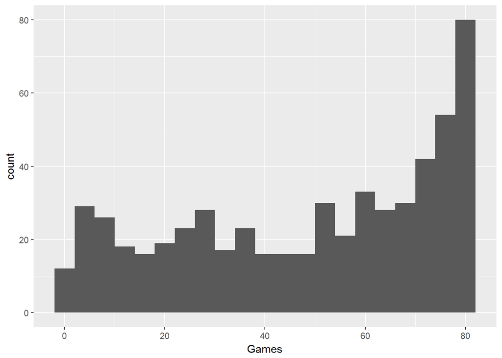

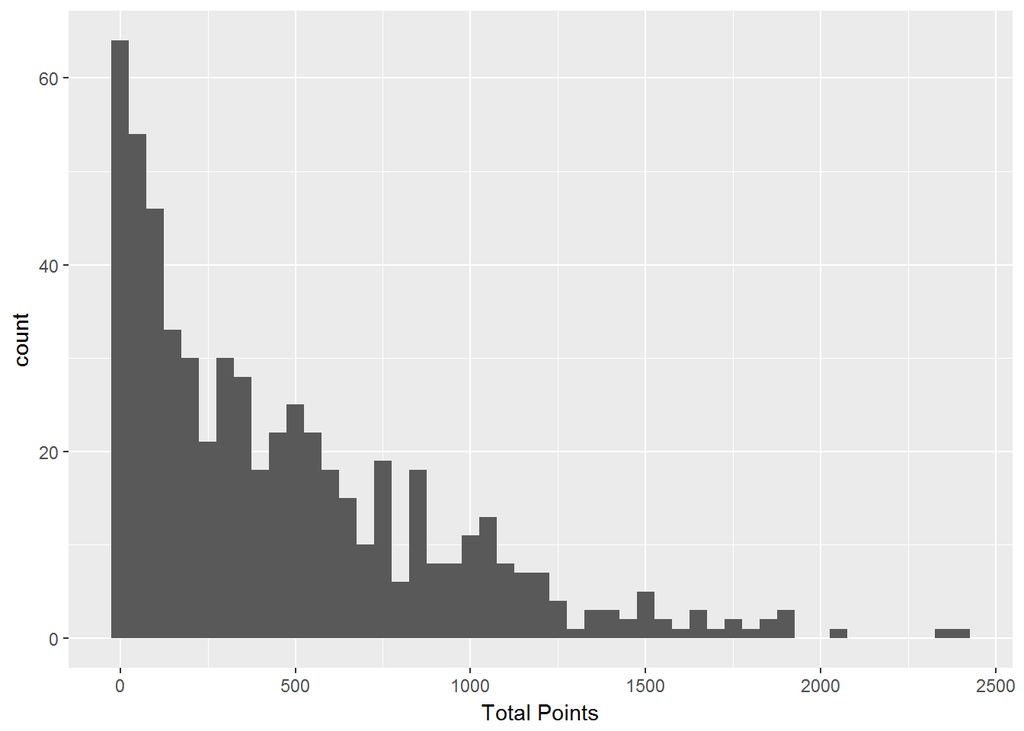

```
##    Min. 1st Qu.  Median    Mean 3rd Qu.    Max.
##     0.0   105.0   338.0   466.3   700.0  2376.0
```

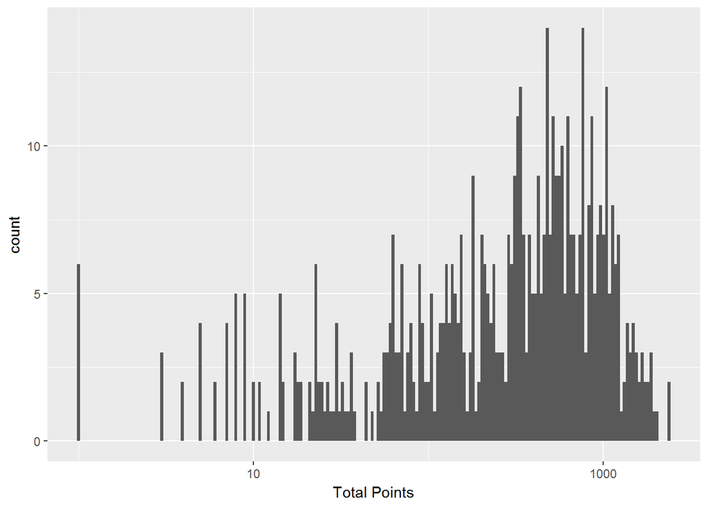

Transformed the long-tail data using log10, to better understand the distribution of total points between players. There seems to be a unimodal peak near 1000 region. Generally, more minutes played, more chance for points an athelete gets. So, how about the minutes played?

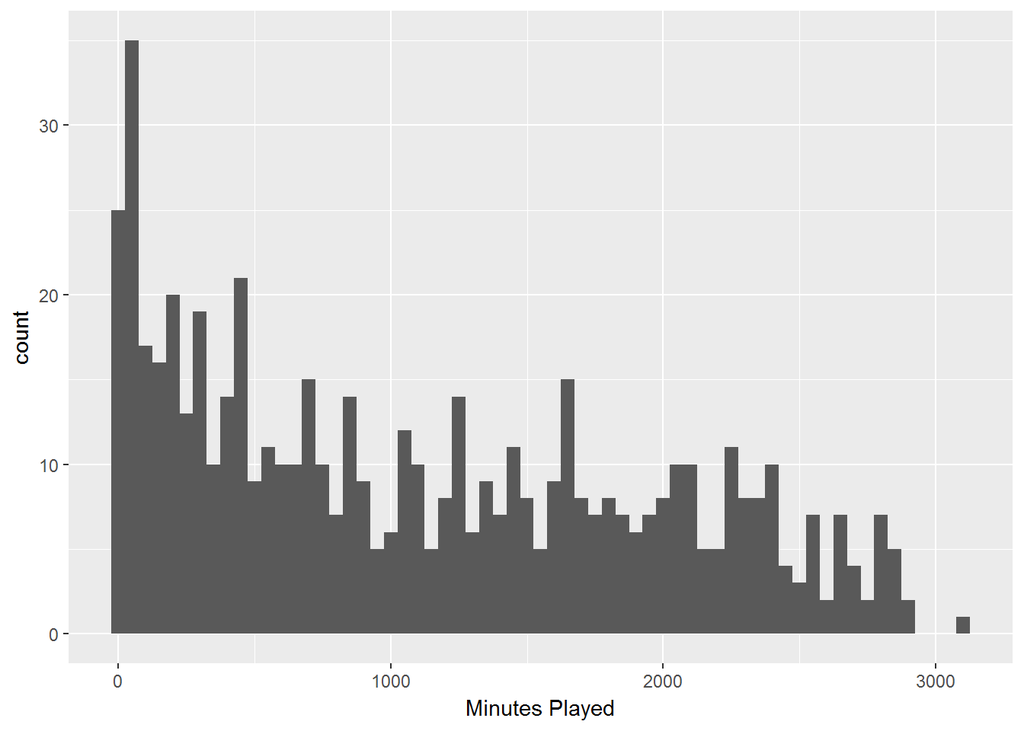

Both total points and minutes played show a similar pyramidic pattern, with only a handful making their way up top. Then, I wonder, would points per minute played be drastically different from those patterns?

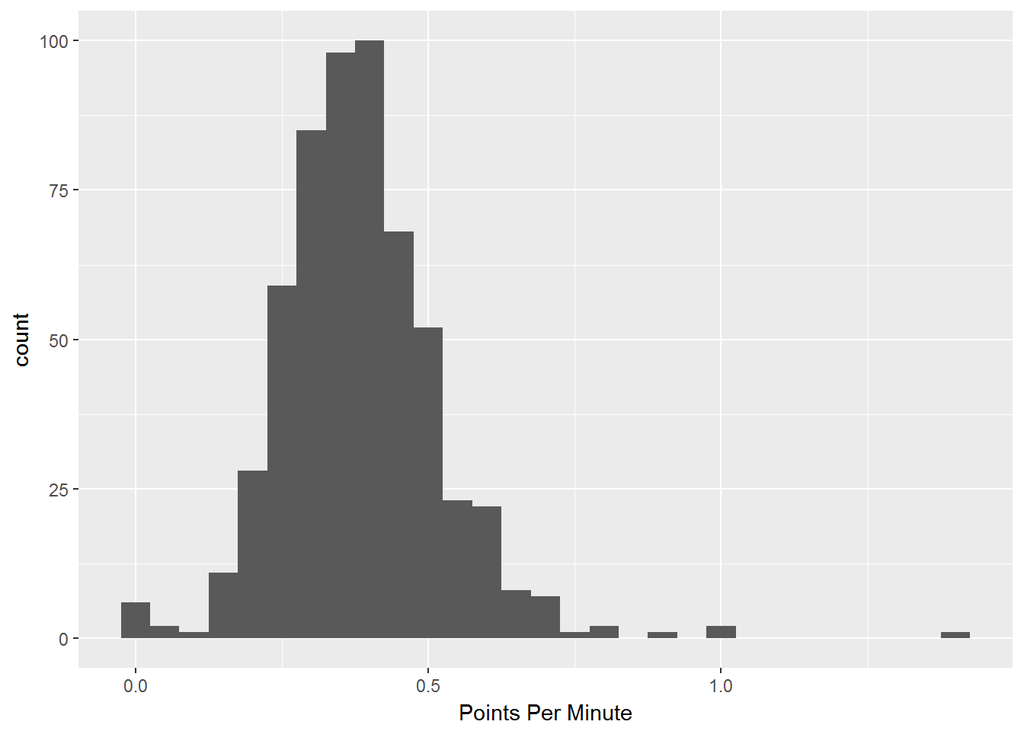

Quite surprisingly, points per minute actually shows a unimodal, normal-like curve with the mean around 0.39, with a few glaring outliers.

```
##    Min. 1st Qu.  Median    Mean 3rd Qu.    Max.
##  0.0000  0.2963  0.3714  0.3841  0.4542  1.4000
```

Now that we examined PTS & minutes played, turning it into point per minute, I want to examine other indicators that conjure up the offense. For field goals, I believe that the FG% is a better indicator of a scorer’s ability than numbers made or attempted, so I will examine that as a main feature of field goal.

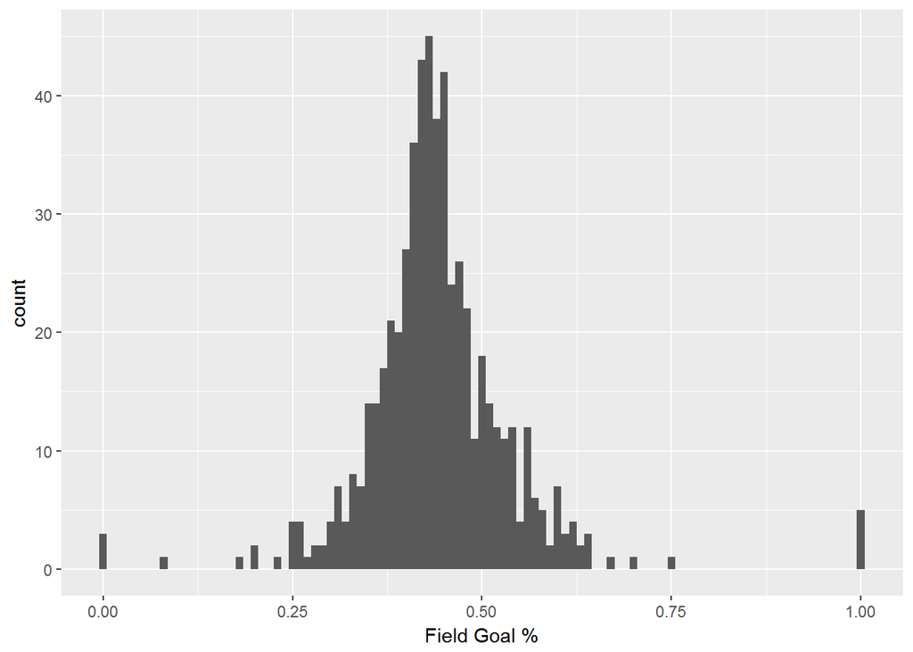

```
##    Min. 1st Qu.  Median    Mean 3rd Qu.    Max.    NA's
##  0.0000  0.3992  0.4350  0.4426  0.4790  1.0000       3
```

```
##               Player Pos Age G GS MP  PER TS. X3PAr FTr ORB. DRB. TRB.
## 23641     Sam Dekker  SF  21 3  0  6 10.8  NA    NA  NA  0.0 18.5  9.2
## 23661    James Ennis  SF  25 3  0  7  2.4  NA    NA  NA  0.0  0.0  0.0
## 24018 Jarnell Stokes   C  22 2  0  4 13.6  NA    NA  NA 27.3 29.8 28.5
##       AST. STL. BLK. TOV. USG. OWS DWS WS WS.48 OBPM DBPM   BPM VORP FG
## 23641    0  8.2    0   NA    0   0   0  0 0.116 -5.3  5.8   0.5    0  0
## 23661   18  0.0    0   NA    0   0   0  0 0.070 -6.1 -4.5 -10.6    0  0
## 24018    0  0.0    0   NA    0   0   0  0 0.163 -3.6 -4.3  -7.8    0  0
##       FGA FG. X3P X3PA X3P. X2P X2PA X2P. eFG. FT FTA FT. ORB DRB TRB AST
## 23641   0  NA   0    0   NA   0    0   NA   NA  0   0  NA   0   1   1   0
## 23661   0  NA   0    0   NA   0    0   NA   NA  0   0  NA   0   0   0   1
## 24018   0  NA   0    0   NA   0    0   NA   NA  0   0  NA   1   1   2   0
##       STL BLK TOV PF PTS height weight PPM       APM       SPM ORPM TPM
## 23641   1   0   0  0   0    206    104   0 0.0000000 0.1666667 0.00   0
## 23661   0   0   0  1   0    201     95   0 0.1428571 0.0000000 0.00   0
## 24018   0   0   0  0   0    206    119   0 0.0000000 0.0000000 0.25   0
##             FPM
## 23641 0.0000000
## 23661 0.1428571
## 24018 0.0000000
```

The NAs in FG. indicate that the athlete did not take any field goals at all. They have 0 attempts, and 0 made.

Similarly, free throw % and 2-pointer / 3-pointer % will be examined instead of made and attempted.

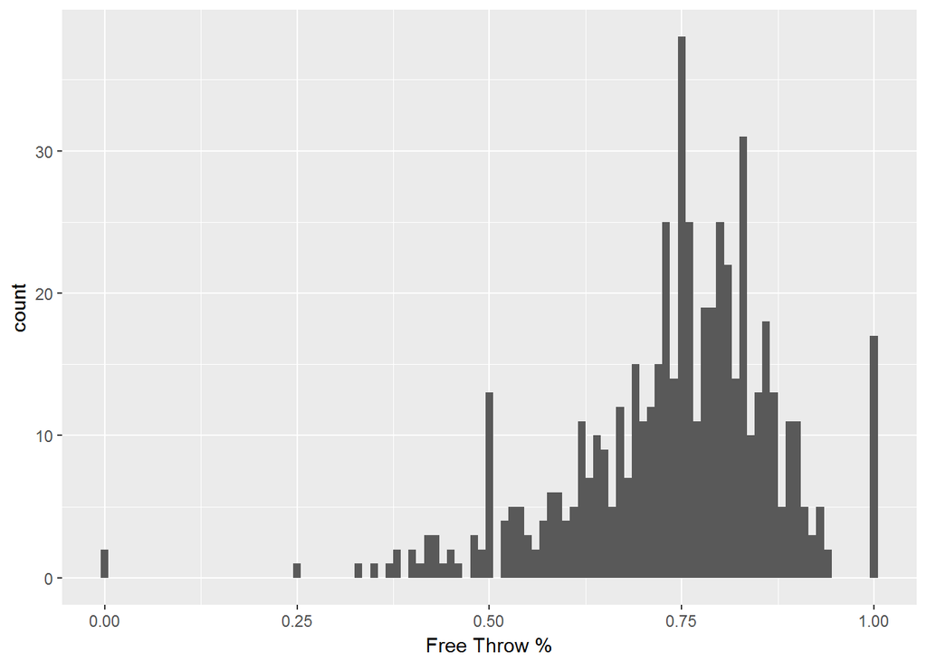

```
##    Min. 1st Qu.  Median    Mean 3rd Qu.    Max.    NA's
##  0.0000  0.6810  0.7570  0.7403  0.8270  1.0000      24
```

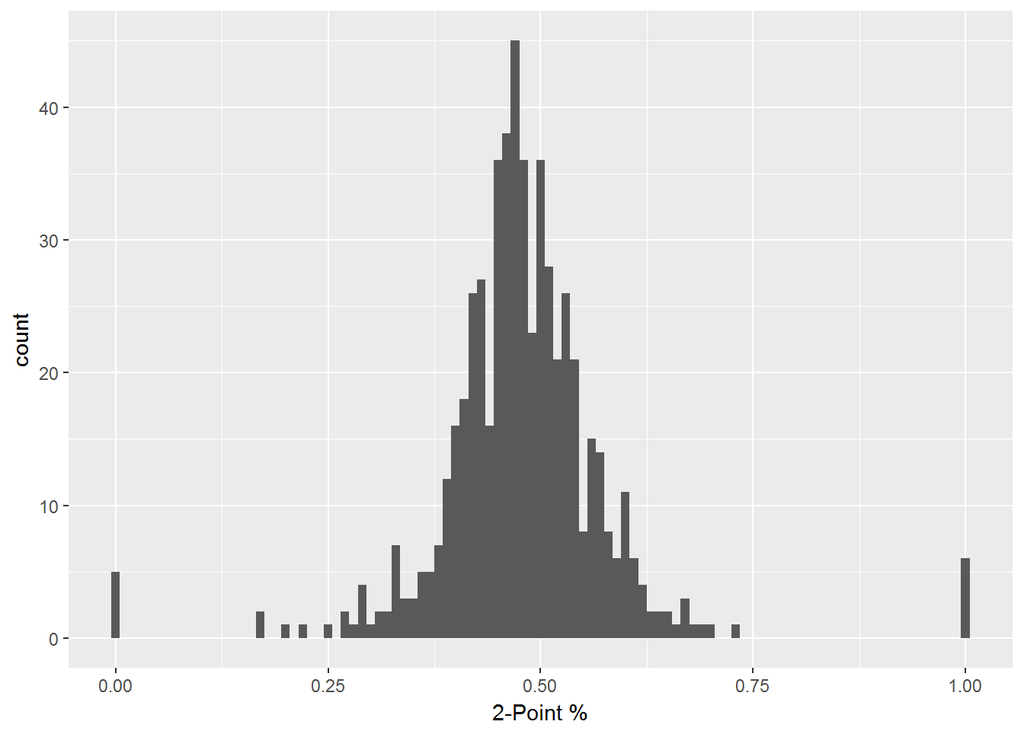

```
##    Min. 1st Qu.  Median    Mean 3rd Qu.    Max.    NA's
##  0.0000  0.4310  0.4750  0.4781  0.5230  1.0000       8
```

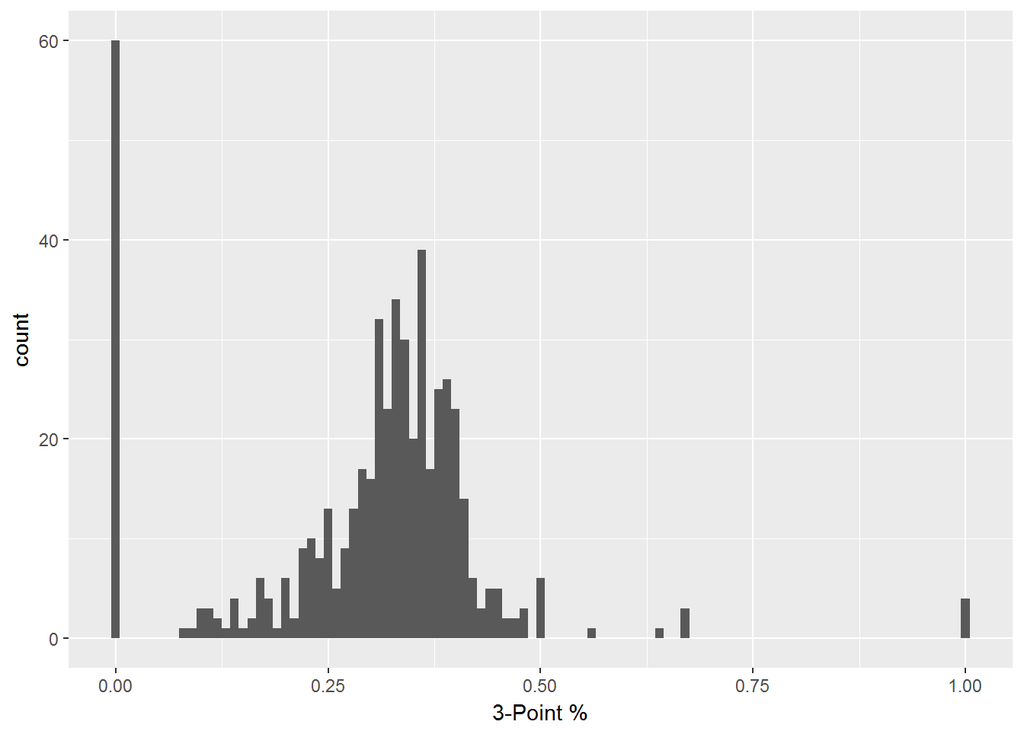

```
##    Min. 1st Qu.  Median    Mean 3rd Qu.    Max.    NA's
##  0.0000  0.2500  0.3290  0.2975  0.3750  1.0000      56
```

All four of the field goal related features show a normal-like curve, with some outliers. However, the number of players with 3-pointer% at 0 are unusually high.

```
## # A tibble: 1 x 1
##       n
##   <int>
## 1    60
```

```
##       X3P         X3PA             X3P.
##  Min.   :0   Min.   : 1.000   Min.   :0
##  1st Qu.:0   1st Qu.: 1.000   1st Qu.:0
##  Median :0   Median : 1.000   Median :0
##  Mean   :0   Mean   : 2.183   Mean   :0
##  3rd Qu.:0   3rd Qu.: 3.000   3rd Qu.:0
##  Max.   :0   Max.   :16.000   Max.   :0
```

Since we checked the field goals already, let’s check other numbers that conjure an offense - assist, steal, offensive rebound, and turnover.

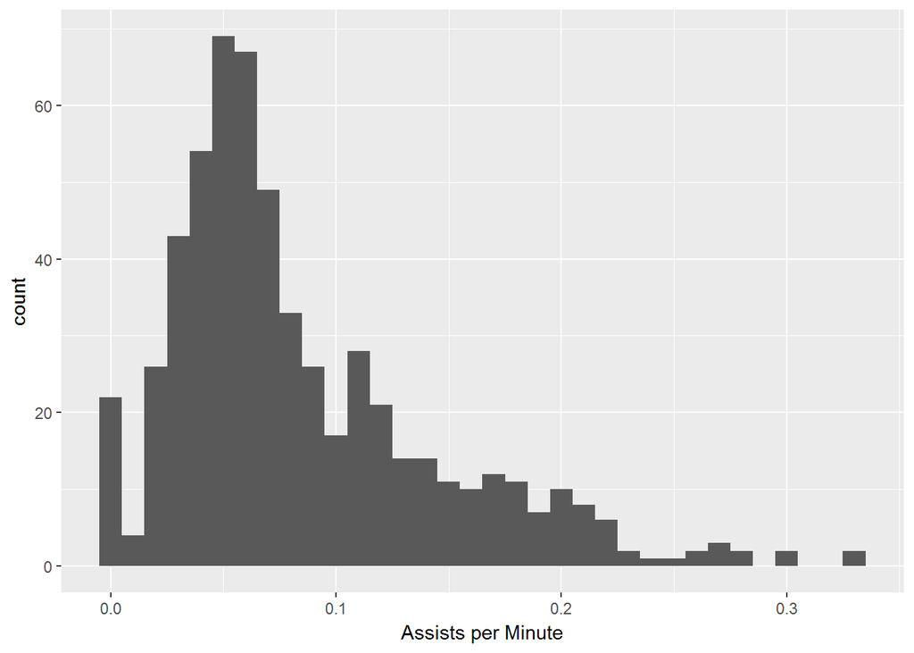

```
##    Min. 1st Qu.  Median    Mean 3rd Qu.    Max.
## 0.00000 0.04412 0.06582 0.08448 0.11234 0.33333
```

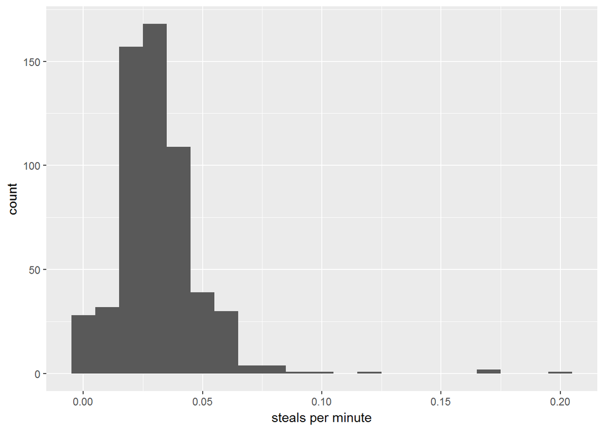

```
##    Min. 1st Qu.  Median    Mean 3rd Qu.    Max.
## 0.00000 0.02207 0.02950 0.03163 0.03833 0.20000
```

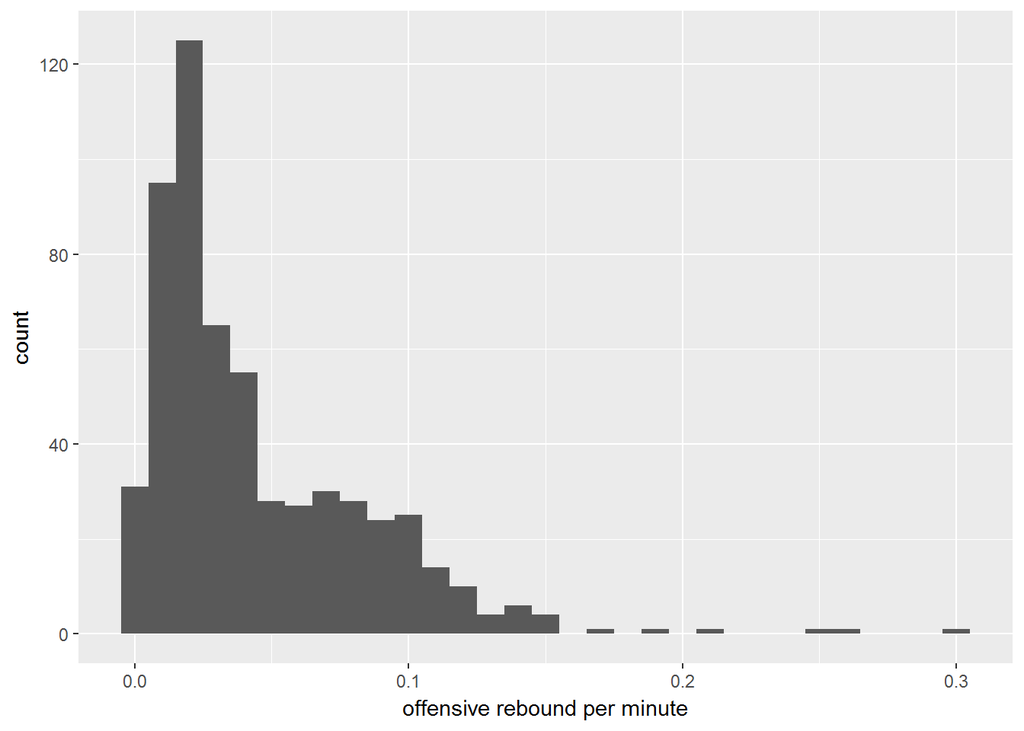

```
##    Min. 1st Qu.  Median    Mean 3rd Qu.    Max.
## 0.00000 0.01606 0.02959 0.04440 0.06766 0.29508
```

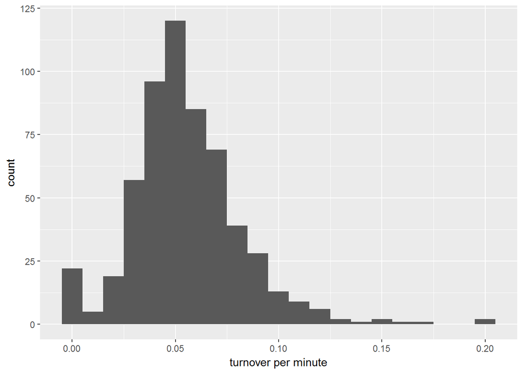

```
##    Min. 1st Qu.  Median    Mean 3rd Qu.    Max.
## 0.00000 0.04029 0.05202 0.05543 0.06957 0.20139
```

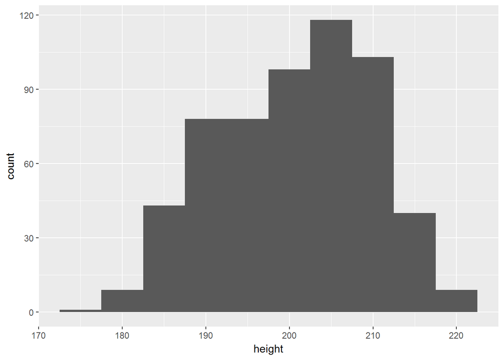

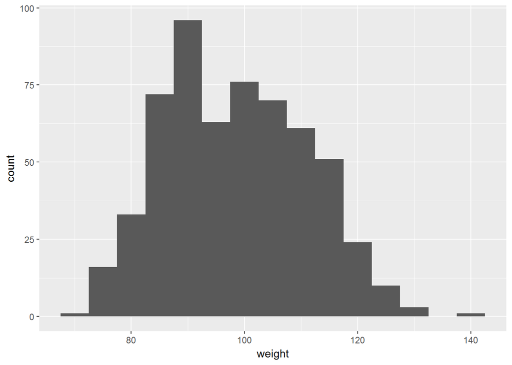

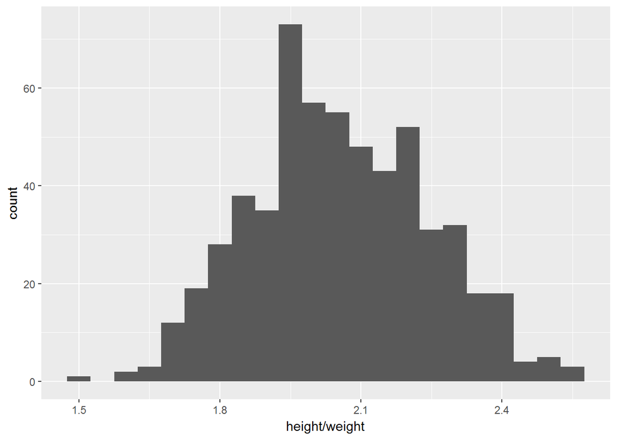

height-weight ratio has a normal-like distribution.

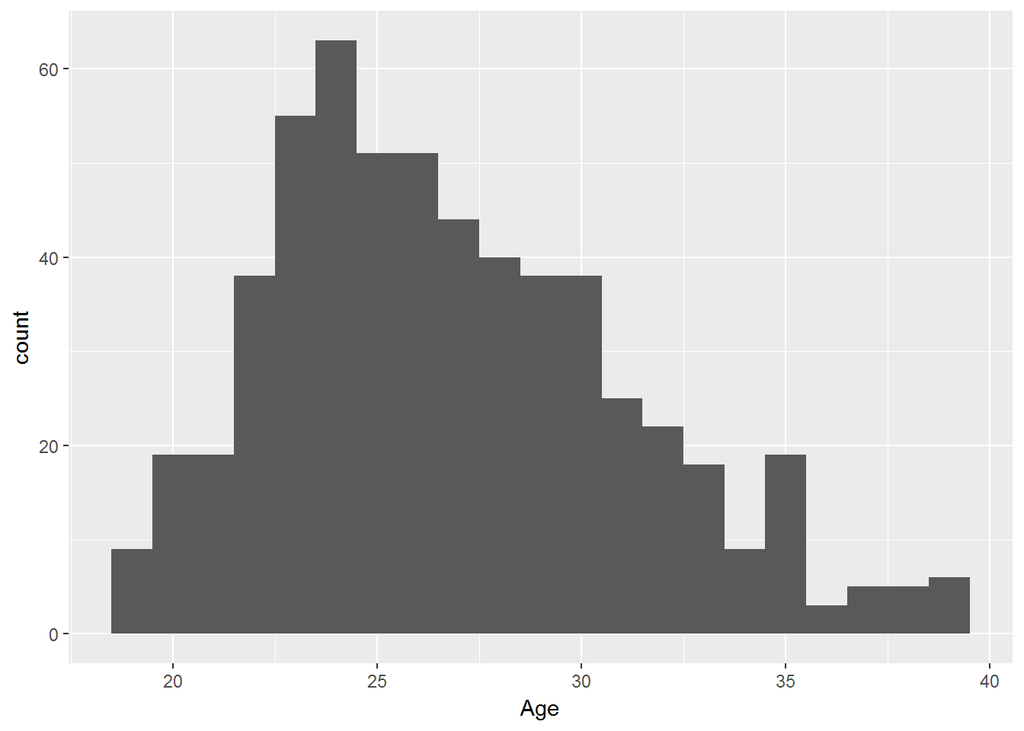

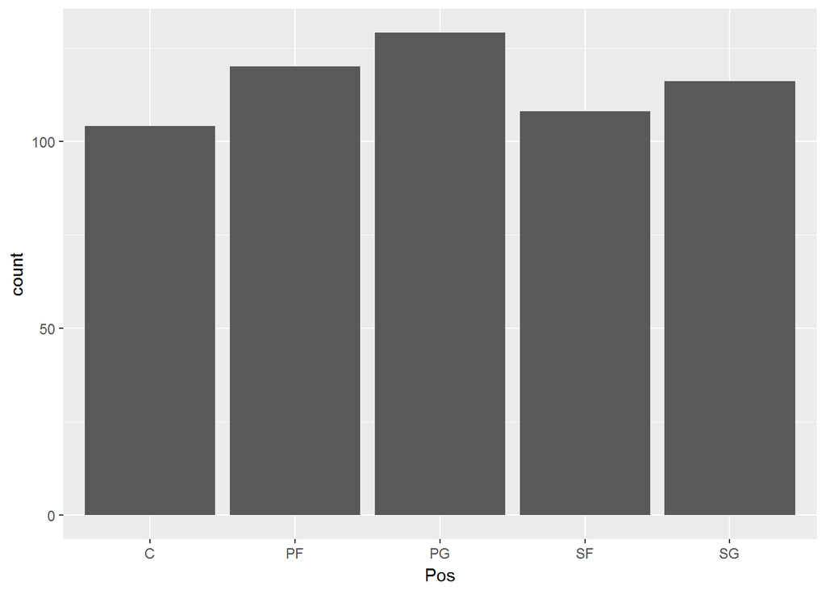

Lack of multi-position players indicates that in modern basketball, position is very specific and well-defined.

# Univariate Analysis

> **Tip**: Now that you’ve completed your univariate explorations, it’s time to reflect on and summarize what you’ve found. Use the questions below to help you gather your observations and add your own if you have other thoughts!

### What is the structure of your dataset?

There are 578 players in the dataset with 56 features. Position is a factor variable with the following level.

```
##  [1] ""      "C"     "C-F"   "C-PF"  "C-SF"  "F"     "F-C"   "F-G"
##  [9] "G"     "G-F"   "PF"    "PF-C"  "PF-SF" "PG"    "PG-SF" "PG-SG"
## [17] "SF"    "SF-PF" "SF-PG" "SF-SG" "SG"    "SG-PF" "SG-PG" "SG-SF"
```

“C”, “C-F”, “C-PF”, “C-SF”, “F”, “F-C”, “F-G”, “G”, “G-F”, “PF”, “PF-C”, “PF-SF”,“PG”, “PG-SF”, “PG-SG”, “SF”, “SF-PF”, “SF-PG”, “SF-SG”, “SG”, “SG-PF”, “SG-PG” “SG-SF”

### What is/are the main feature(s) of interest in your dataset?

The main features in the data set are points per minute and field goal percentage, which is divisible into two-pointer % and three-pointer %. I want to determine which features are the best for predicting the points per minute for a player. I suspect that the field goal percentage, along with some other variables, will affect the points per minute, thereby help build a predictive model for the points scored.

### What other features in the dataset do you think will help support your investigation into your feature(s) of interest?

I believe that the performance features that I’ve explored above, such as steals, and offensive rebounds, will support my investigation into points per minute and field goal percentage.

### Did you create any new variables from existing variables in the dataset?

Points per minute(PPM) variable was derived from (total points scored / minutes played). This is a better indicator of the athlete’s proficiency in scoring than total points scored, which can be biased by the length of their playing time. Also, assist / steal / offensive rebounds / turnover are all converted to a per minute metric.

### Of the features you investigated, were there any unusual distributions? Did you perform any operations on the data to tidy, adjust, or change the form of the data? If so, why did you do this?

# Bivariate Plots Section

Before we dive into the variables, let’s make sense of the correlation of our main variable, points per minute(PPM), to other possibly affecting variables.

```
##          PPM          Age          FG.          FT.         X3P.
##  1.000000000 -0.058005365  0.405434454  0.263494016  0.299904146
##         X2P.         ORPM          APM          SPM          TPM
##  0.213442253 -0.033946823  0.108099194 -0.089584691  0.302964815
##          FPM       height       weight
## -0.076065931  0.001557562  0.018977750
```

Pearson’s correlation of variables against PPM shows that there two indicators showing modest correlation - field goal percentage (FG.) and turnovers per minute(TPM).

There are three interesting things to note: 1. Field goal percentage as a whole has much higher correlation, when compared to the broken down components of field goal percentage : 2-pointer percentage and 3-pointer percentage.

2. Turnover has a relatively high correlation with points per minute, which is quite surprising - generally, one would think that having more turnovers would undermine one’s ability to score.
3. Physical profile such as height & weight, is seemingly unrelated with the athletes’ point scoring ability.

Let’s examine the first point, with field goal percentage, 2-pointer percentage, and 3-pointer percentage in relation to point per minute.

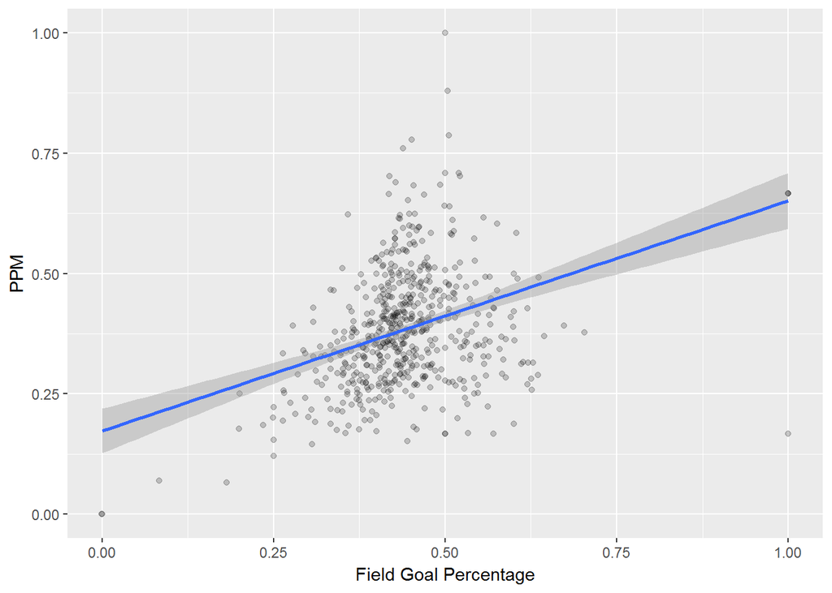

To take a closer look at the main area, let’s zoom in:

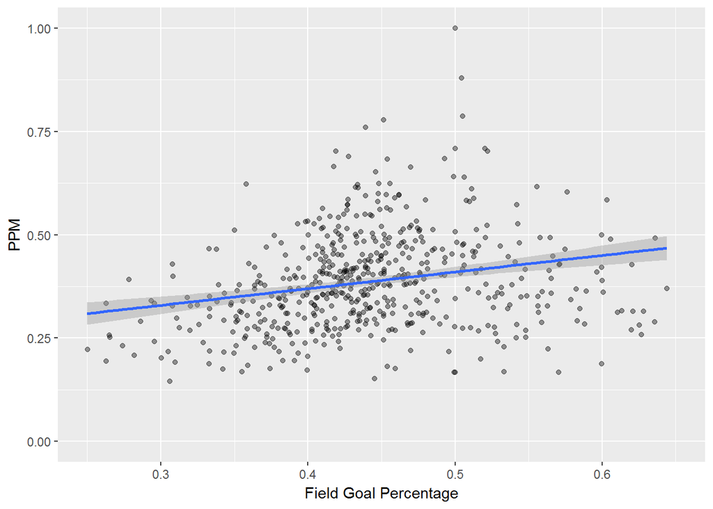

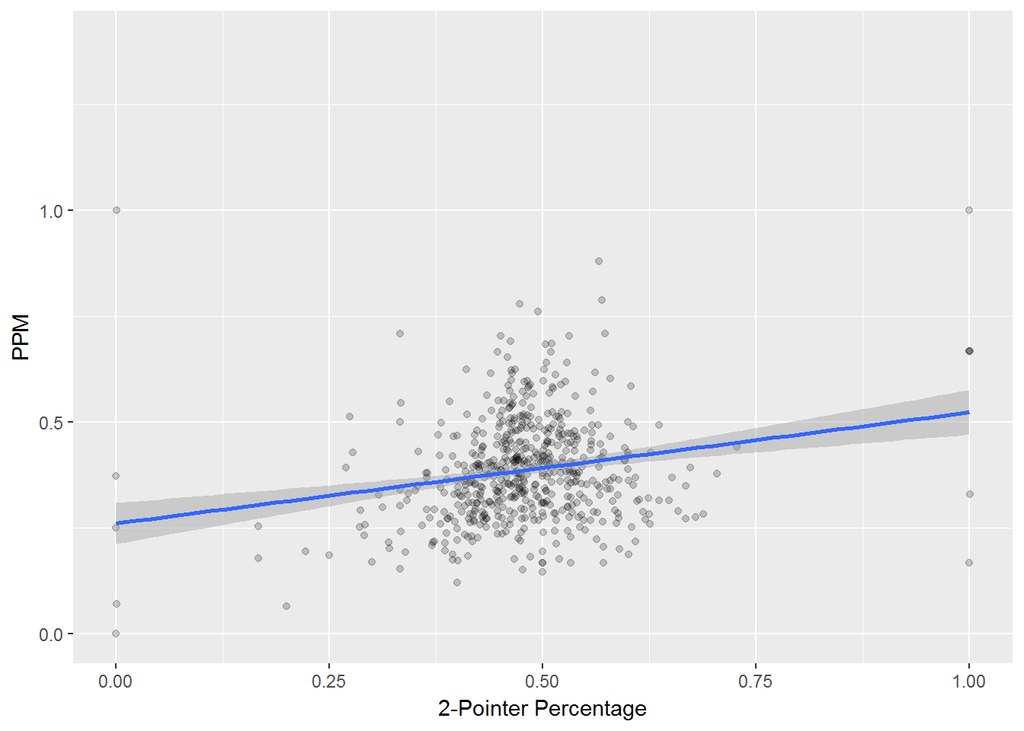

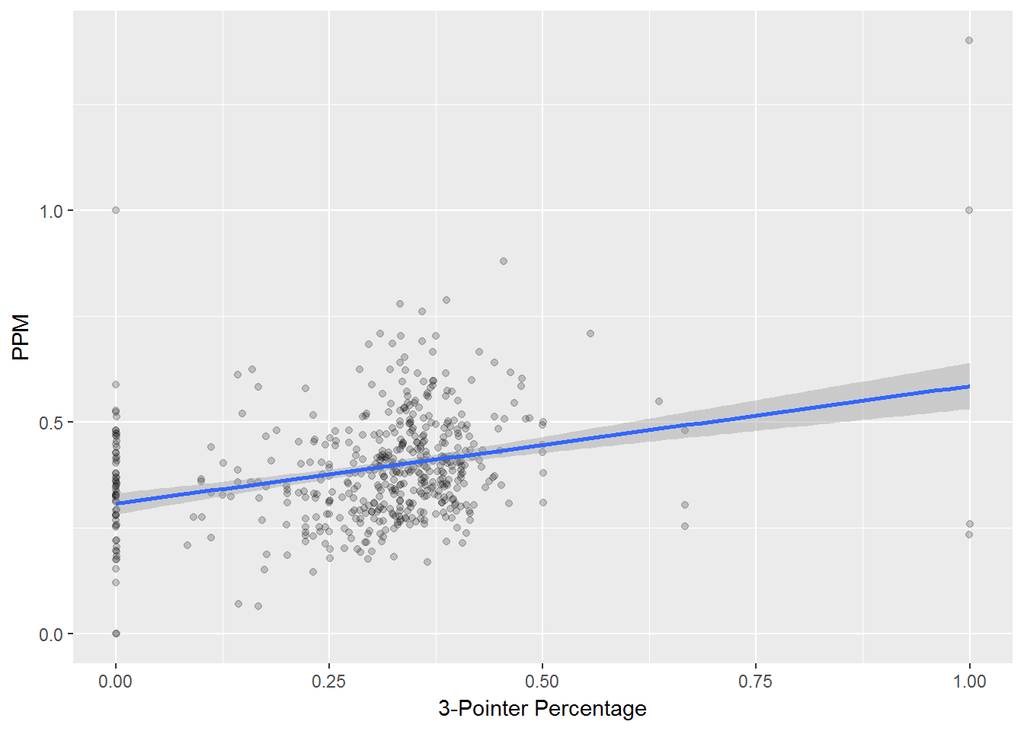

Field Goal Percentage is defined by (X2P + X3P) / (X2PA + X3PA), thus is related directly to 2-pointer percentage, defined by (X2P / X2PA), and 3-pointer percentage, defined by (X3P / X3PA). Thus, when linear modelling, including field goal percentage along with 2-pointer percentage and 3-pointer percentage will likely cause a colinearity issue. Since Field Goal Percentage has higher correlation with point per minute, it might as well be one of our choice of the variables in linear model.

Now, we can address our second point in question - that is, the question of high correlation between turnover per minute(TPM) and point per minute. It is quite counter-intuitive, as turnover generally means that you coughed up your ball, and in general, ball handling is emphasized in the pro scene.

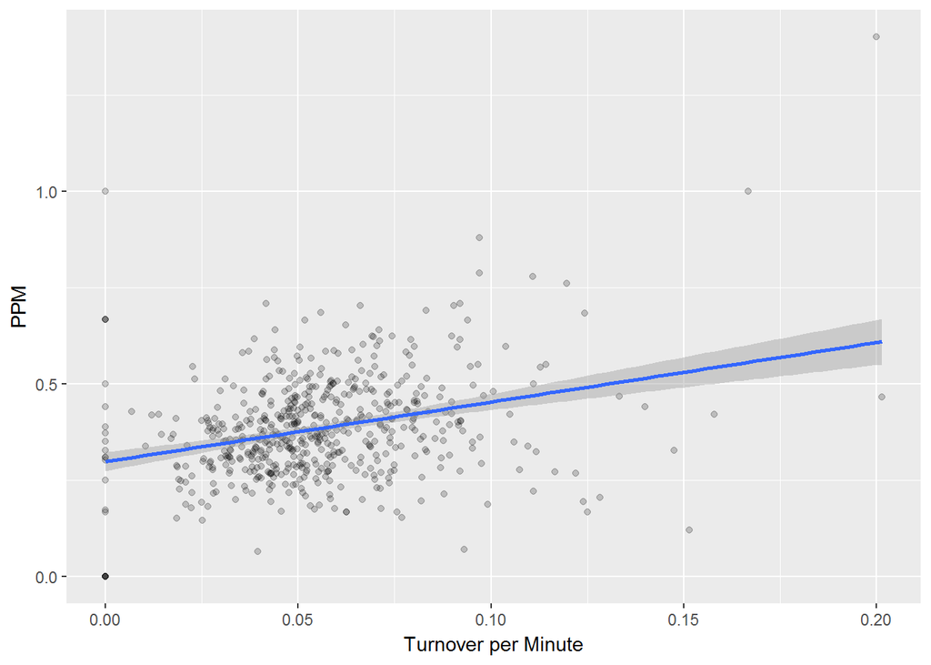

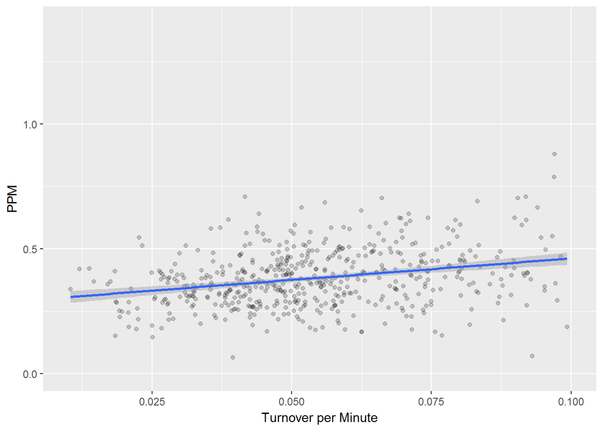

The tendency seems even clearer, even though there seems to be a spread towards the higher end, a bit like a cone shape. Let’s examine some of the high TOM personnels, in top 90% percentile.

```
##               Player Pos Age  G GS   MP  PER   TS. X3PAr   FTr ORB. DRB.
## 1    Jimmer Fredette  SG  26  2  0    5 47.4 1.094 1.000 5.000  0.0  0.0
## 2        Coty Clarke  SF  23  3  0    6 23.9 0.750 0.500 0.000  0.0 18.0
## 3      Stephen Curry  PG  27 79 79 2700 31.5 0.669 0.554 0.250  2.9 13.6
## 4       Kevin Durant  SF  27 72 72 2578 28.2 0.634 0.348 0.361  2.0 21.8
## 5   DeMarcus Cousins   C  25 65 65 2246 23.6 0.538 0.158 0.498  7.7 28.2
## 6       James Harden  SG  26 82 82 3125 25.3 0.598 0.406 0.518  2.2 15.6
## 7       LeBron James  SF  31 76 76 2709 27.5 0.588 0.199 0.347  4.7 18.8
## 8     Damian Lillard  PG  25 75 75 2676 22.2 0.560 0.414 0.315  1.8 10.4
## 9  Russell Westbrook  PG  27 80 80 2750 27.6 0.554 0.236 0.397  6.1 18.1
## 10       Paul George  SF  25 81 81 2819 20.9 0.557 0.391 0.364  3.1 18.7
##    TRB. AST. STL. BLK. TOV. USG.  OWS DWS   WS WS.48 OBPM  DBPM  BPM VORP
## 1   0.0  0.0  0.0  0.0 23.8 38.0  0.1 0.0  0.1 0.514 19.5 -10.7  8.8  0.0
## 2   8.8  0.0  0.0  0.0 20.0 35.5  0.0 0.0  0.0 0.025  0.2  -9.7 -9.5  0.0
## 3   8.6 33.7  3.0  0.4 12.9 32.6 13.8 4.1 17.9 0.318 12.4   0.1 12.5  9.8
```

[output cut: 40 more lines]

Except for some the outliers whose game stinct was quite brief, you find some interesting names - Curry, KD, DeMarcus, Harden, LeBron James, and so on. These athletes are entrusted with leading the charge, the primary ball handlers. Thus, high turnover per minute is quite natural to them.

This is the summary of point per minute, for athletes with high turnovers per minute:

```
##    Min. 1st Qu.  Median    Mean 3rd Qu.    Max.
## 0.06977 0.32461 0.42136 0.45907 0.54981 1.40000
```

This is the summary of point per minute, over whole dataset:

```
##    Min. 1st Qu.  Median    Mean 3rd Qu.    Max.
##  0.0000  0.2963  0.3714  0.3841  0.4542  1.4000
```

```
##         PPM         Age         FG.         FT.        X3P.        X2P.
##  0.30296482 -0.06412419 -0.01797782  0.03624693 -0.02914496 -0.11731209
##        ORPM         APM         SPM         TPM         FPM      height
## -0.14064393  0.49283256  0.20586063  1.00000000 -0.00496249 -0.17340249
##      weight
## -0.14493494
```

Furthermore, the correlation between turnover per minute and assist per minute is even higher than that between turnover per minute and points per minute. This is also quite reasonable, as our list of top turnover per minute athletes were the primary ball handlers for the team, leading attack and responsible for scoring and creating for teammates.

How about the positions? We know that positions define the role, with the centers and power forwards operating nearer to the goal. Guards, generally, operate on the perimeter. Does the position of an athlete have any impact?

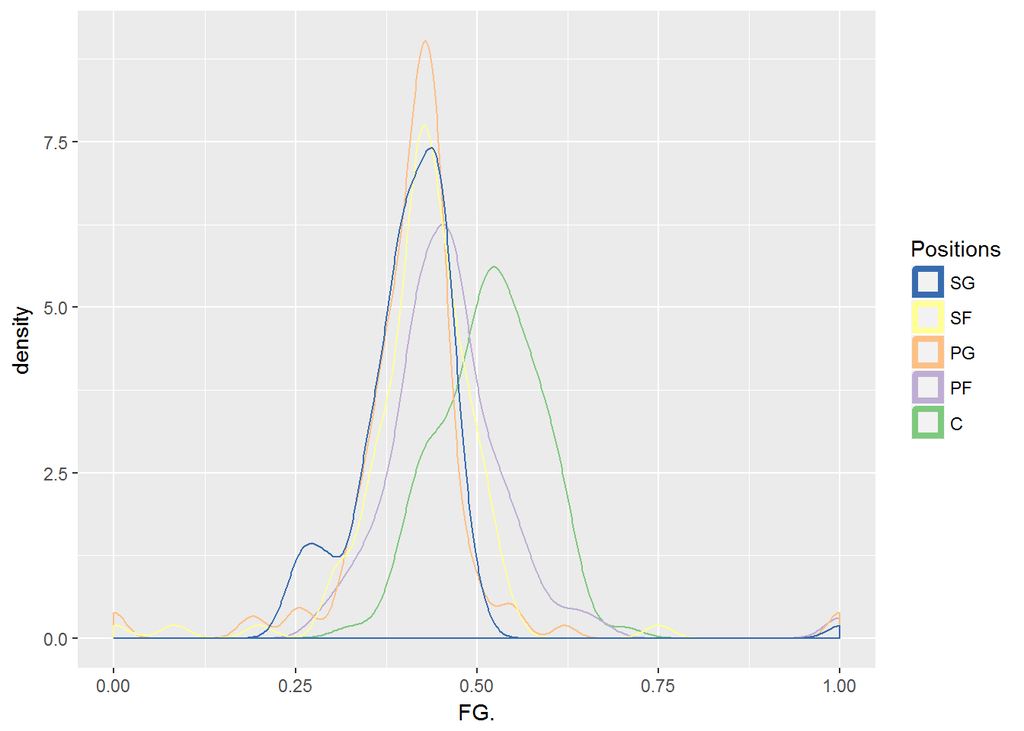

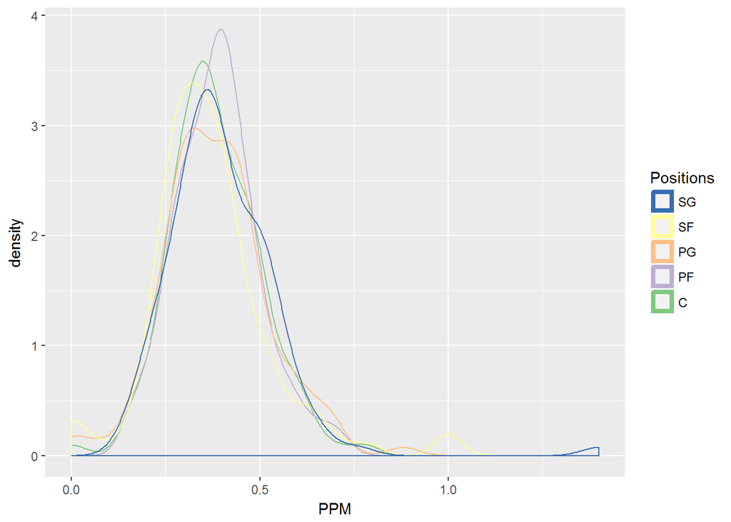

This density plot shows an odd trend in field goal percentage and point per minute concerning centers. The centers, while having point per minute density similar to other positions, have higher field goal percentage compared to the other positions.

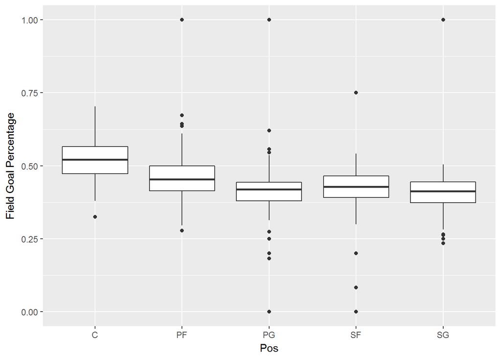

This difference is even more stark when looking at box plot for field goal percentage, segmented by positions. Centers have a very high inter-quartile range, with the median way above the other positions. This relationship between field goal percentage, point per minute, and position poses an interesting question, and thus will be examined further in the multivariate section.

# Bivariate Analysis

### Talk about some of the relationships you observed in this part of the investigation. How did the feature(s) of interest vary with other features in the dataset?

My main feature of interest, points per minute, had moderate positive correlation with field goal percentage (FG.) and turnovers per minute(TPM), both positive. Also, it had positive correlation with free throw percentage, as well.

### Did you observe any interesting relationships between the other features (not the main feature(s) of interest)?

Turnovers per minute(TPM) has a strong positive correlation with assist per minute(APM), which is quite plausible as the athletes whose turnovers per minute was the highest were the primary ball handlers for their team. Also, centers had higher field goal percentage relatively.

### What was the strongest relationship you found?

# Multivariate Plots Section

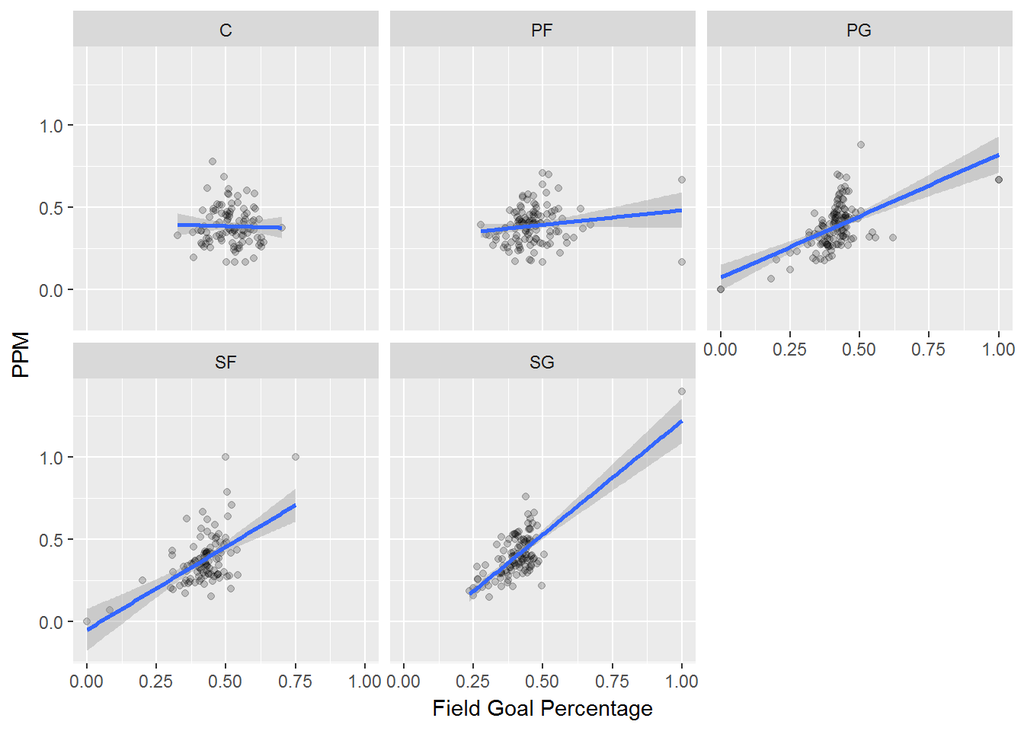

As you can see, for most of the positions, field goal percentage seems to have a positive linear correlation with points per minute. However, for center position, the field goal percentage does not show such a correlation. The correlation between points per minute and field goal percentage, for centers, is small as shown below:

```
## [1] -0.02924458
```

Excluding the centers, the correlation between points per minute and field goal percentage becomes quite strong:

```
## [1] 0.4929063
```

This is greater than the correlation as whole.

This, along with the plots of field goal percentage and positions done at the bivariate section, implies that centers generally have higher field goal percentage when compared to other positions. It is reasonable, as centers, generally, shoot a lot closer to the rim than most of the other positions.

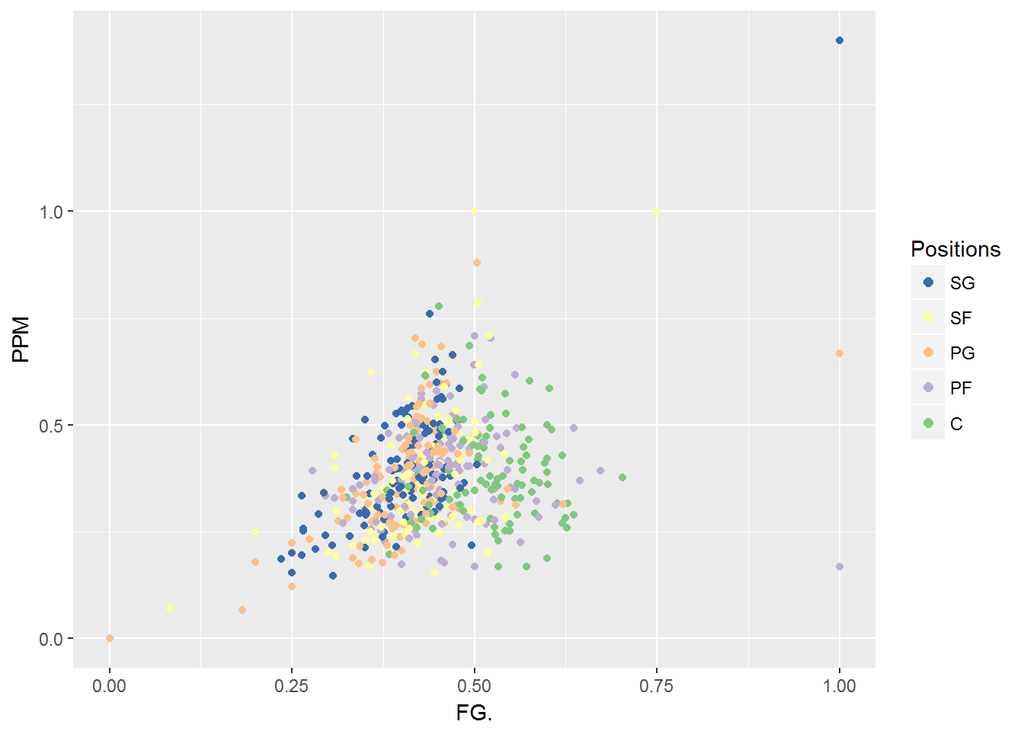

When visualized, centers reside much closer to the lower-right cluster of field goal percentage - point per minute plot, with higher field goal percentage and lower point per minute. Also, higher spread compared to other positions, if not regarding the outliers.

The field goal percentage, as a whole, shows a weak linear relationship with the points per minute, meaning that it can be, indeed, a variable which can be used to predict the point per game. However, given the big spread, the statistical power of the model will be quite weak.

```
##
## Calls:
## m1: lm(formula = (PPM ~ FG.), data = df)
## m2: lm(formula = PPM ~ FG. + TPM, data = df)
## m3: lm(formula = PPM ~ FG. + TPM + FT., data = df)
## m4: lm(formula = PPM ~ FG. + TPM + Pos, data = df)
##
## ======================================================================
##                       m1           m2           m3           m4
## ----------------------------------------------------------------------
##   (Intercept)        0.141***     0.057*      -0.165***    -0.044
##                     (0.024)      (0.025)      (0.041)      (0.031)
##   FG.                0.553***     0.560***     0.538***     0.659***
##                     (0.052)      (0.049)      (0.057)      (0.053)
##   TPM                             1.460***     1.527***     1.603***
##                                  (0.183)      (0.176)      (0.192)
##   FT.                                          0.309***
##                                               (0.034)
##   Pos: PF/C                                                 0.049**
##                                                            (0.016)
##   Pos: PG/C                                                 0.036*
##                                                            (0.016)
##   Pos: SF/C                                                 0.066***
##                                                            (0.017)
##   Pos: SG/C                                                 0.091***
##                                                            (0.017)
## ----------------------------------------------------------------------
##   R-squared          0.164        0.248        0.291        0.290
##   adj. R-squared     0.163        0.245        0.287        0.283
##   sigma              0.123        0.117        0.104        0.114
##   F                112.519       94.122       75.115       38.682
##   p                  0.000        0.000        0.000        0.000
##   Log-likelihood   387.804      418.042      470.030      434.741
##   Deviance           8.702        7.832        5.915        7.389
##   AIC             -769.609     -828.083     -930.061     -853.482
##   BIC             -756.551     -810.673     -908.484     -818.661
##   N                574          574          553          574
## ======================================================================
```

The model can only explain 29.1% of the variance in the point per minute. There might be a feature which we have missed, or not exactly keeping track of as a statistics right now. Using per minute stat does not change the r-squared much from adding both field goals attempted and field goals made, in place of per minute stats.

# Multivariate Analysis

### Talk about some of the relationships you observed in this part of the investigation. Were there features that strengthened each other in terms of looking at your feature(s) of interest?

Position, generally, posed no noticable difference for points per minute. However, the correlation of field goal percentage and points per minute on centers were really small by comparison.

In other positions, field goal percentage generally went with points per minute.

### Were there any interesting or surprising interactions between features?

Field goal percentage by position. Centers had really high field goal percentage and I think closer shots taken by the centers are the reason for it.

### OPTIONAL: Did you create any models with your dataset? Discuss the strengths and limitations of your model.

I’ve tried modelling with linear regression, but r-squared is .29 - there should be some major feature / indicator that we missed, or could not find from the current stats.

# Final Plots and Summary

### Plot One

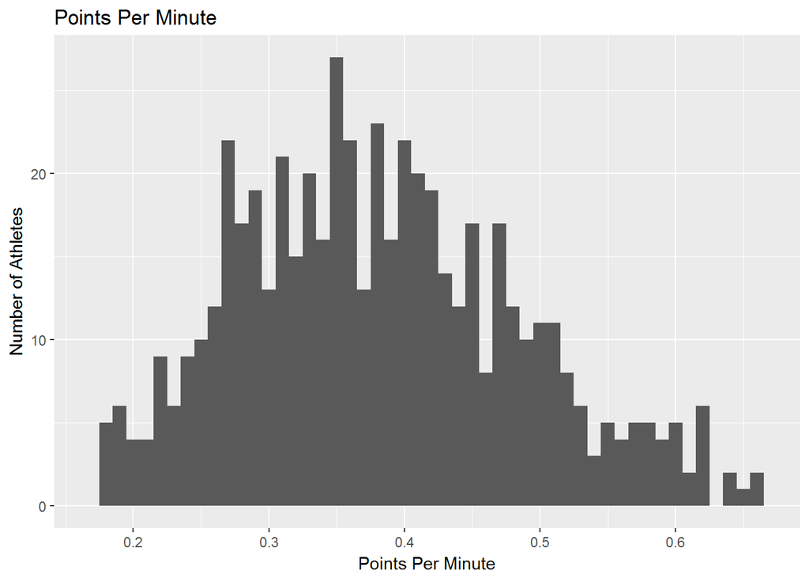

### Description One

The distribution of points per minute shows a unimodal data, indicating that the athletes have normal-like distribution for their expected points per minute.

### Plot Two

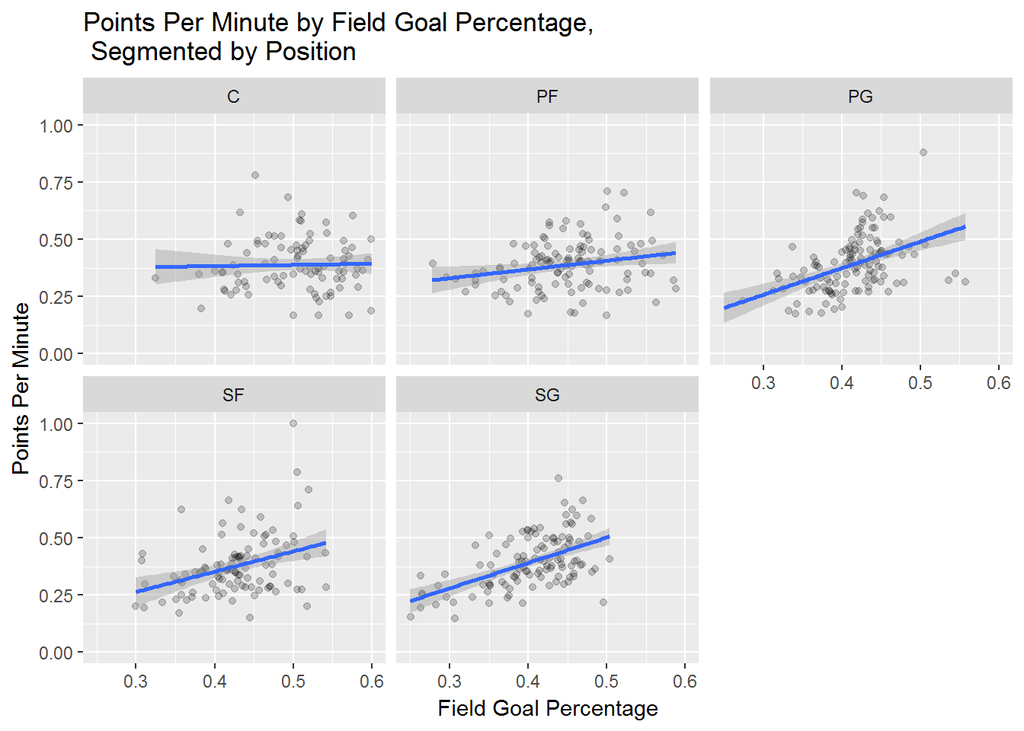

### Description Two

While points per minute and field goal percentage generally have a positive correlation, for centers it is rather neutral, with almost flat correlation. For the centers, their field goal percentage is bunched up to the right side of our x-axis, meaning that they generally have higher field goal percentage, and their spread is a bit wider, showing no consistent relationship.

### Plot Three

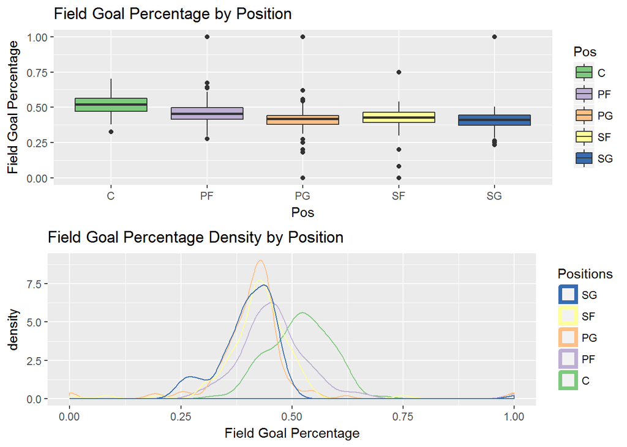

### Description Three

Athletes with position Center(C) has the highest median field goal percentage. A greater proportion of centers have higher field goal percentage. There are less outliers in center position, as well.

# Reflection

This dataset contains information on all players and their stats from 1950 - 2017(partial). However, to better reflect modern basketball, I’ve only used 2016-2017 as my sample. I started by looking through individual variables, making estimates on which variable might be impactful on my main variable, which was point per minute.

The trend between field goal percentage and points per minute was found, albeit not very strong. I was surprised by the fact that the position actually had a big impact on field goal percentage. Centers were, in general, more efficient in scoring field goals then others. I hoped I have a bit more data to dive in and elaborate on this phenomenon. Average shooting distance, for example, would be a great feature to have and analyze - I’m quite sure this is what contributed to the scoring efficiency of the centers.

There are some limitations with this approach: This season may be an abnormality when compared to other seasons. Also, it is based on the game statistics, which can be bolstered by the addition of several features. Also, my model was quite off, primarily due to the data having great spread in terms of field goal percentage and points per minute.